# Forecast Provenance

Here’s a quick look at forecast provenance in the EFI challenge

```r
library(tidyverse)
library(rdflib)
library(ggraph)
library(tidygraph)
```

Forecast provenance is recorded in JSON-LD using the DCAT2 vocabulary. This is a widely used technical standard but probably unfamiliar to most domain scientists. (If you’re feeling curious, you may like [A tidyverse lover’s introduction to RDF](https://cran.r-project.org/web/packages/rdflib/vignettes/rdf_intro.html)).

Anyway, we could read the file in as plain JSON, but turns out it is a lot more powerful to read in as RDF, so here goes:

```r
x <- rdf_parse("https://data.ecoforecast.org/forecasts/aquatics/prov.json")
```

This allows us to write *semantic* queries, in a language kinda like SQL but with magic variables.

Here, we say:

1. find the `id` of everything with a title matching this pattern `aquatics-2021-0*-01-EFInull.csv.gz`.
2. For each such object, find out which activity generated the object
3. for that activity, determine what files it *used* as input and which ones it *generated* as output,
4. for both input and output, extract the identifier, title, and description and give that back to me as columns.

```r
nodes <- rdf_query(x,
                   'PREFIX dc: <http://purl.org/dc/terms/>
 PREFIX prov: <http://www.w3.org/ns/prov#>
 SELECT DISTINCT ?identifier ?title ?description
 WHERE { ?id dc:title ?forecast .
         FILTER regex(?forecast, "aquatics-2021-0[0-9]-01-EFInull.csv.gz") .
         ?id prov:wasGeneratedBy ?activity .
         ?activity prov:used ?input .
         ?activity prov:generated ?output .
         {
           ?input dc:identifier ?identifier .
           ?input dc:title ?title .
           ?input dc:description ?description .
         } UNION {
           ?output dc:identifier ?identifier .
           ?output dc:title ?title .
           ?output dc:description ?description .
         }
        }'
)
nodes
```

| identifier | title | description |
| --- | --- | --- |
| hash://sha256/b5ba53db95d418c3bb1390924759ecbad3dc8785b89e87623e32ee396c9fe18a | 03_generate_null_forecast_aquatics.R | R code |
| hash://sha256/8645545aad437f282a8426d4ec93e67638adabe68e55cdd03bc4d288ed81761b | aquatics-2021-02-01-EFInull.csv.gz | output data |
| hash://sha256/85726856743ab0f44a90dcf4fe1fc0bbdcbd47f0e834b1cd5c24614510595f26 | aquatics-targets.csv.gz | Input data |
| hash://sha256/1870ac5bfc4a5c54ba003db73c818a793a74069bb61864f2b6a6dc75e1e70b4c | aquatics-2021-02-01-EFInull.csv.gz | output data |
| hash://sha256/95ac4042ef034573cbfae129f7383414d20e737a9bc9e0b4afd50348e687aa96 | aquatics-targets.csv.gz | Input data |
| hash://sha256/ba17bf6a1a0e87f6df510da19e49696be0ab4ea6e7850def1be4ed37ca4872a0 | 03_generate_null_forecast_aquatics.R | R code |
| hash://sha256/4eb91aa61865d9b8257f7163492296d48eba1b8341a68b12408f85bb6e7f3d18 | aquatics-2021-01-01-EFInull.csv.gz | output data |
| hash://sha256/719d0e95997cfee8ef57c3972e996ba577a43c33ada07de74cafea6b9fa00770 | aquatics-targets.csv.gz | Input data |
| hash://sha256/f01e3018ffcefe1b1a0c0c061a165039a454e61b6a2903975d0ee8b05688a969 | aquatics-2021-02-01-EFInull.csv.gz | output data |
| hash://sha256/28701bd5559ad88cca36a6daec85e68ab44c4cc90efb6852c36e37971cc12270 | aquatics-targets.csv.gz | Input data |

[output cut: 24 more lines]

Kinda cool! So what do we have? Let’s tabulate by `title`, which in this case is the familiar filename we use to refer to each object. Note that we often generate multiple versions of the same file over time, which are distinguished by different (content-based) identifiers

```r
nodes %>% count(title)
```

| title | n |
| --- | --- |
| 03_generate_null_forecast_aquatics.R | 3 |
| aquatics-2021-01-01-EFInull.csv.gz | 4 |
| aquatics-2021-02-01-EFInull.csv.gz | 4 |
| aquatics-2021-03-01-EFInull.csv.gz | 6 |
| aquatics-2021-04-01-EFInull.csv.gz | 1 |
| aquatics-2021-05-01-EFInull.csv.gz | 1 |
| aquatics-targets.csv.gz | 15 |

We have 3 versions of the code, and 15 versions of the target data, which have produced between 1 - 6 versions of each forecast file! However, this summary doesn’t really show us which code produced which outputs. We can get a bit better handle on this by trying to visualize the data.

First, let’s just grab and edge list. (This could have been extracted from the previous data, but it’s “easy” to just write a new query)

```r
edges <- rdf_query(x,
                   'PREFIX dc: <http://purl.org/dc/terms/>
 PREFIX prov: <http://www.w3.org/ns/prov#>
 SELECT DISTINCT ?from ?to
 WHERE { ?id dc:title ?forecast .
         FILTER regex(?forecast, "aquatics-2021-0[0-9]-01-EFInull.csv.gz") .
         ?id prov:wasGeneratedBy ?activity .
         ?activity prov:used ?from .
         ?activity prov:generated ?to .
        }'
)
edges
```

| from | to |
| --- | --- |
| hash://sha256/b5ba53db95d418c3bb1390924759ecbad3dc8785b89e87623e32ee396c9fe18a | hash://sha256/8645545aad437f282a8426d4ec93e67638adabe68e55cdd03bc4d288ed81761b |
| hash://sha256/85726856743ab0f44a90dcf4fe1fc0bbdcbd47f0e834b1cd5c24614510595f26 | hash://sha256/8645545aad437f282a8426d4ec93e67638adabe68e55cdd03bc4d288ed81761b |
| hash://sha256/b5ba53db95d418c3bb1390924759ecbad3dc8785b89e87623e32ee396c9fe18a | hash://sha256/1870ac5bfc4a5c54ba003db73c818a793a74069bb61864f2b6a6dc75e1e70b4c |
| hash://sha256/95ac4042ef034573cbfae129f7383414d20e737a9bc9e0b4afd50348e687aa96 | hash://sha256/1870ac5bfc4a5c54ba003db73c818a793a74069bb61864f2b6a6dc75e1e70b4c |
| hash://sha256/ba17bf6a1a0e87f6df510da19e49696be0ab4ea6e7850def1be4ed37ca4872a0 | hash://sha256/4eb91aa61865d9b8257f7163492296d48eba1b8341a68b12408f85bb6e7f3d18 |
| hash://sha256/719d0e95997cfee8ef57c3972e996ba577a43c33ada07de74cafea6b9fa00770 | hash://sha256/4eb91aa61865d9b8257f7163492296d48eba1b8341a68b12408f85bb6e7f3d18 |
| hash://sha256/ba17bf6a1a0e87f6df510da19e49696be0ab4ea6e7850def1be4ed37ca4872a0 | hash://sha256/f01e3018ffcefe1b1a0c0c061a165039a454e61b6a2903975d0ee8b05688a969 |
| hash://sha256/28701bd5559ad88cca36a6daec85e68ab44c4cc90efb6852c36e37971cc12270 | hash://sha256/f01e3018ffcefe1b1a0c0c061a165039a454e61b6a2903975d0ee8b05688a969 |
| hash://sha256/b5ba53db95d418c3bb1390924759ecbad3dc8785b89e87623e32ee396c9fe18a | hash://sha256/e2a3d4ca9cc8f2e652819cd87e0cd91a565c0952d0c20f0b9beae90157f01a0f |
| hash://sha256/6736e6b2cfebec831d8f069133801117f03cbecb84a4f9fee659a839f1ee6197 | hash://sha256/e2a3d4ca9cc8f2e652819cd87e0cd91a565c0952d0c20f0b9beae90157f01a0f |

[output cut: 23 more lines]

## Visualizing Provenance

With a list of nodes and edges, we can plot the graph with standard `ggraph` tactics:

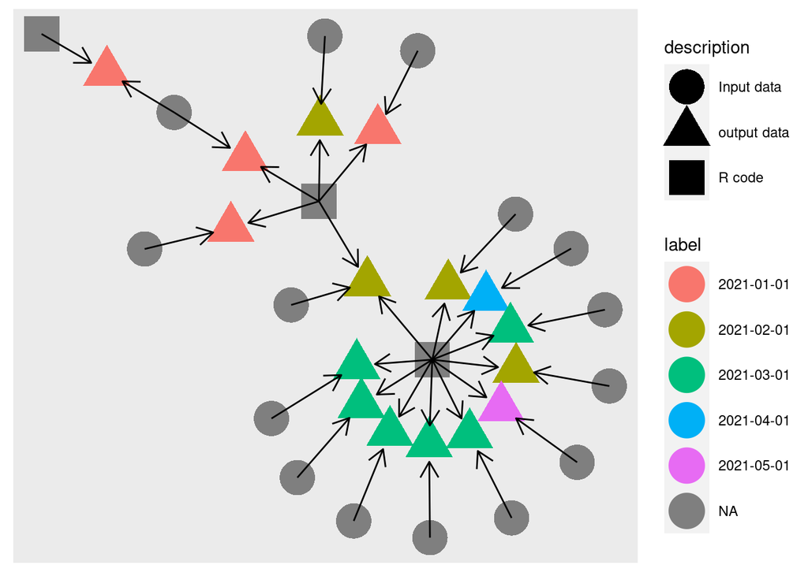

```r
node_df <- nodes %>% mutate(label = str_extract(title, "\\d{4}-\\d{2}-\\d{2}"))
gr <- tbl_graph(edges = edges, nodes = node_df, directed = TRUE)


ggraph(gr,  layout = 'kk') +
  geom_node_point(aes(x = x, y = y, shape=description, col=label), size=10) +
  geom_edge_link(arrow = arrow(length = unit(4, 'mm')),
                 end_cap = circle(4, 'mm'))
```

Here’s what we can see from this graph:

Not shown is that the code is run many more times each month, but generates the identical output from identical input (code and target data)

# Publishing forecasts

Using content-based identifiers, there is no need to pre-register a forecast identifier. Each file has an identifier from the moment it is created. Each unique data object is uniquely identified by it’s content hash now, which lets us access each specific version from the EFI content store, and each object *can still be accessed* by it’s identifier once it is deposited in an appropriate database. It just remains to decide how to “chunk” the objects into “packages” that each get a DOI.

We could upload all 34 objects in a single package with one DOI. (Or at the opposite extreme, upload each separately, though that seems a poor choice). Or we could sub-divide them, e.g. allowing each unique set of input data, code, output data to get a unique DOI (note that this would cause packages to share some elements, particularly the code file, which changes least frequently.